# Tvyal Newsletter

Aghasi Tavadyan

2024-02-09

*English summary below.*

Հարգելի գործընկեր,

Հուսով եմ լավ եք: Ներկայացնում եմ այս շաբաթվա վերլուծությունները և աշխատանքները.

1. 💹💳 Մասնավոր աշխատատեղերի 76 տոկոսը Երևանում է
2. English summary

## 1. 💹💳 Մասնավոր աշխատատեղերի 76 տոկոսը Երևանում է

### Գնաճով ճշտված աշխատավարձերի վերլուծություն

Հարկ է նշել, որ պետական հատվածում աշխատատեղերի համամասնությունը շարունակաբար նվազել է 2002 թվականից ի վեր, երբ գրանցված աշխատատեղերի մոտավորապես 70 տոկոսը աշխատում էր պետական հատվածում։ 2022 թվականին պետական աշխատատեղերը կազմել են ընդհանուրի 30,3 տոկոսը։ Կրճատումը պայմանավորված է ոչ թե պետական հատվածում աշխատատեղերի թվի նվազմամբ, այլ գրանցված ոչ պետական աշխատատեղերի աճով: Պետական հատվածի աշխատողների թիվը 2020-22 թվականների ընթացքում աճել է 3,2 տոկոսով, մինչդեռ ոչ պետական հոտվածի աշխատատեղերը աճել են 12,8 տոկոսով: 2022 թվականին գրանցված է եղել 684783 աշխատող, որը նախորդ տարվա համեմատ ավել է 5,4 տոկոսով։

**Գծապատկեր 1.** Պետական ոլորտի աշխատողների տեսակարար կշիռը Հայաստանում

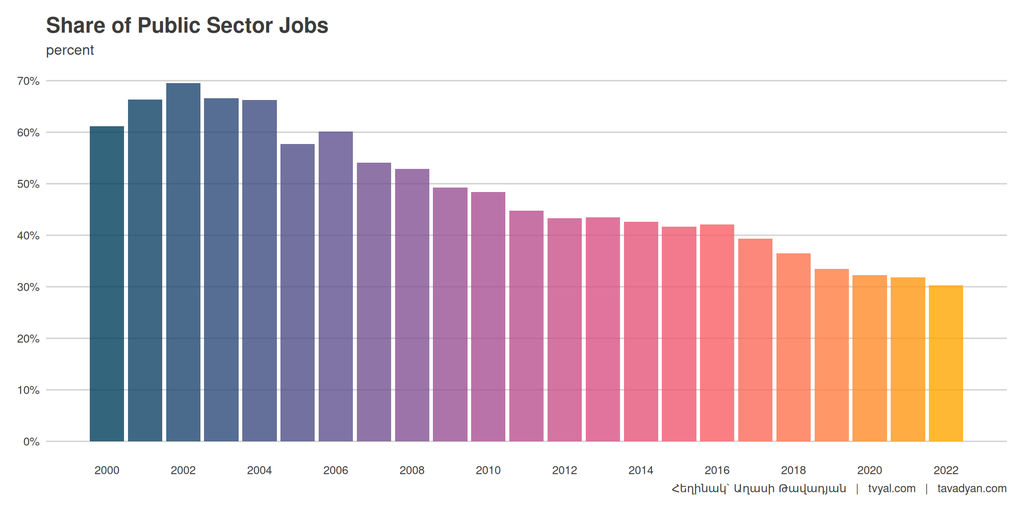

**Գծապատկեր 2.** Զբաղվածությունն ըստ մարզերի

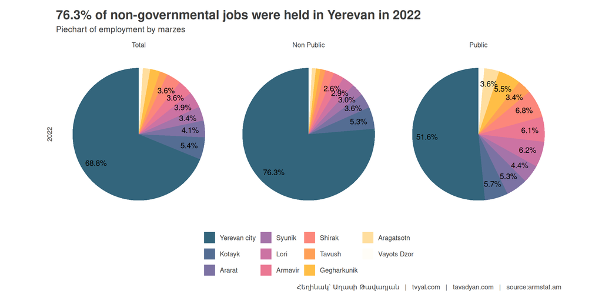

Վերջին երեք տարում (2022թ.՝ 2019թ.-ի համեմատ) աշխատատեղերը մարզերում աճել են ընդամենը 4,7 տոկոսով, իսկ Երևանում՝ 19,5 տոկոսով։ Մարզերում մասնավոր հատվածի աշխատատեղերը աճել են 7,2 տոկոսով, մինչդեռ Երևանում աճն ավելի էական է եղել՝ 24,5 տոկոս։ Աշխատատեղերի ամենաքիչ աճը գրանցվել է Լոռիում՝ ընդամենը 2,5 տոկոս աճ։ Այս ընթացքում Արարատի մարզում պետական հատվածում աշխատատեղերն աճել են 6,4 տոկոսով՝ հասնելով 10975 աշխատողի, իսկ Երևանում՝ 101744 աշխատողից հասնելով 107039 աշխատողի՝ 5,2 տոկոս աճով։

Դիտարկենք միջին ամսական անվանական աշխատավարձն ըստ մարզերի և տնտեսության ճյուղերի։ Դիտարկված են իրական աշխատավարձերը, որոնք կշռվել են 2022 թվականի գնողունակությամբ։

Ինչպես երևում է գծապատկերում՝ 2022 թվականին պետական հատվածի իրական միջին աշխատավարձերը նվազել են բոլոր մարզերում։ Այս անկման վրա ազդել է 2022 թվականին գրանցված 8,3 տոկոս գնաճը։ Պետական հատվածում միջին աշխատավարձը 2022 թվականին կազմել է 186940 դրամ, անվանական աճը կազմել է 4,3 տոկոս։ Սակայն իրական աճը նվազել է -4 տոկոսով։

2023 թվականին արձանագրվել է 0,6 տոկոս գնանկում, ինչը չի նվազեցրել իրական աշխատավարձերի աճը։ Եթե հաշվի առնենք որ 2023 թվականին պետական հատվածում աշխատավարձերը նույնպես ապահովել են 4 տոկոս աճ և չի գրանցվել գնաճ, ապա պետական ոլորտի աշխատավարձերը պետք է համադրվեն 2021 թվականի գնողունակության հետ: Հարկ է նշել, որ 2022 թվականին 207591 մարդ կամ գրանցված ընդհանուր աշխատուժի 30.3 տոկոսը գրանցված է եղել պետական հատվածում։

Կարևոր է նշել, որ 0,6 տոկոս գնանկումը չի համընկնում ՀՀ պետական բյուջեի մասին օրենքի 4-րդ հոդվածի հետ, որը պահանջում է «առաջնորդվել 12-ամսյա գնաճի 4±1.5 տոկոսային կետ տատանումների թույլատրելի միջակայքում նպատակային ցուցանիշով»:

**Աղյուսակ 3.** Միջին ամսական անվանական աշխատավարձը ըստ մարզերի և տնտեսության հատվածների

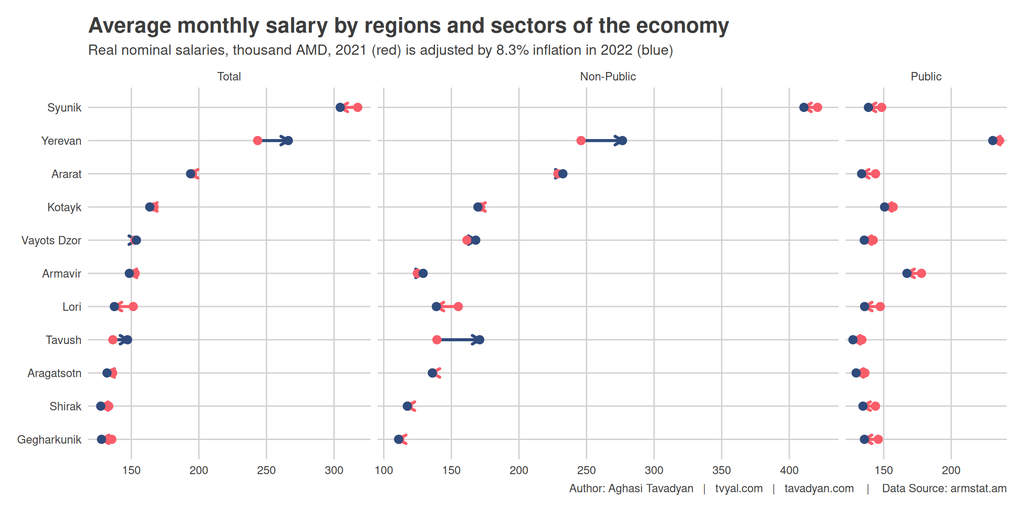

> Նշենք որ այս վերլուծությունը տնային տնտեսությունների վերլուծության 3-րդ մասն է։

> Նախորդ վերլուծությունները կարդացեք այստեղ․
> 1. [🏠💰📉 Տնային տնտեսությունները աղքատացել են](https://www.tvyal.com/newsletter/2024/2024_01_07)
> 2. [👨‍👩‍👧‍👦✨ Ամուր ընտանիք․ հարուստ ընտանիք](https://www.tvyal.com/newsletter/2024/2024_01_26)

**Գծապատկեր 4.** Ոչ պետական և պետական աշխատատեղերի հարաբերությունը:

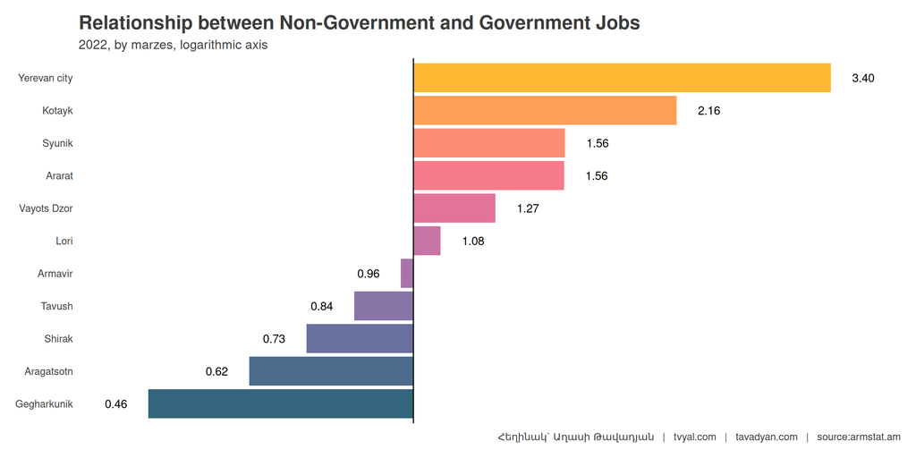

Դիտարկենք միջին աշխատավարձը ըստ տնտեսական գործունեության։ 2022 թվականին տեղեկատվության և կապի, ինչպես նաև ֆինանսական ծառայությունների ոլորտները գրանցել են ամենաբարձր և ամենաարագ աճը՝ անվանական աշխատավարձի աճը այս ոլորտներում եղել է համապատասխանաբար 35% և 33,7%:

2022 թվականին ֆինանսների և ապահովագրության ոլորտում աշխատում էր 21449 մարդ, իսկ տեղեկատվության և կապի ոլորտում՝ 40301 մարդ։ Տեղեկատվություն և կապը կազմել էր ընդանուր գրանցված աշխատողների 5.9%-ը։ Այս հատվածն ունի ամենաբարձր միջին աշխատավարձը՝ 748235 դրամ: Հատկանշական է, որ ՏՏ-ին բաժին է ընկել այս ոլորտի 71,1 տոկոսը (28668 աշխատող)։ ՏՏ ոլորտում միջին աշխատավարձը 2022 թվականին կազմել է 917192 դրամ: 2023 թվականին ՏՏ միջին աշխատավարձը արդեն գերազանցել է 1 միլիոն դրամը։ Եթե ՏՏ ոլորտը հանենք Տեղեկատվության և հաղորդակցության շրջանակից, ապա միայն կապի ոլորտում միջին աշխատավարձը կազմել էր 331 863 դրամ։

**Գծապատկեր 5.** Միջին ամսական աշխատավարձը ըստ տնտեսական գործունեության

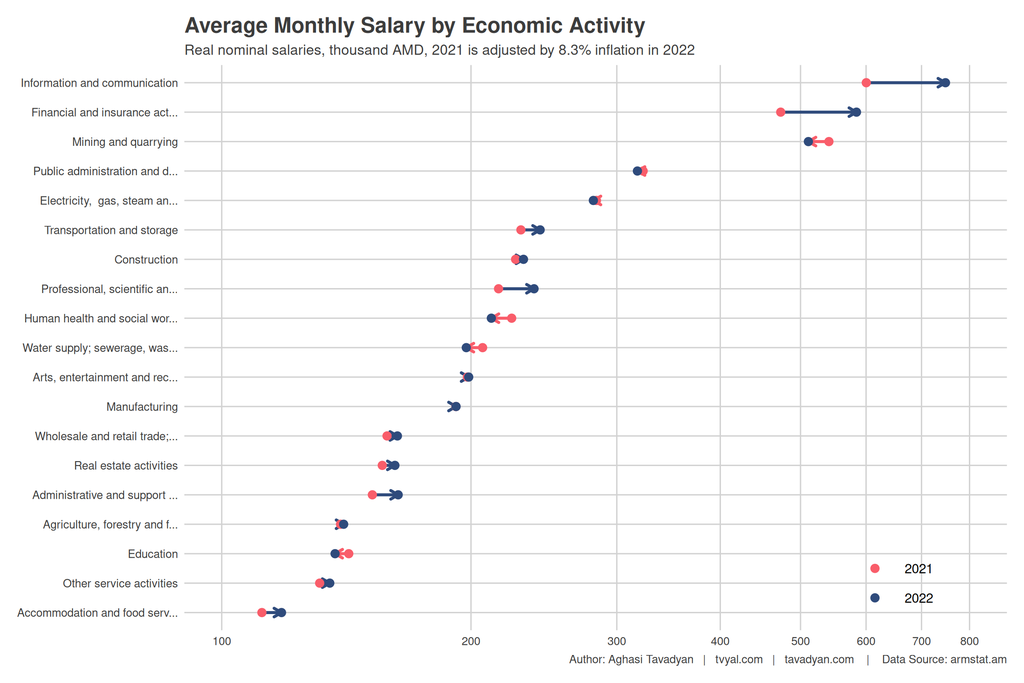

Մինչև 2021 թվականը կրթության ոլորտը ամենամեծ գործատուն էր՝ 116445 մարդ աշխատողով, որը կազմում էր աշխատուժի 17%-ը։ 2022 թվականին “Մեծածախ և մանրածախ առևտուր, ավտոմեքենաների և մոտոցիկլների նորոգում” ոլորտը դարձավ ամենախոշոր գործատուն, այստեղ աշխատում էր 121953 մարդ կամ 2022թ․ աշխատուժի 17,8%-ը։

Կրթության ոլորտը առաջնահերթ նշանակություն ունի ապագա սերունդներին կրթելու տեսանկյունից և այս ոլոտում աշխատում են աշխատուժի ավելի քան 17 տոկոսը: Այս ոլորտում միջին ամսական անվանական աշխատավարձը (ներառյալ հարկերը) 2022 թվականին կազմել է ընդամենը 132,756 ՀՀ դրամ։ Հաշվի առնելով գնաճը նախորդ տարվա համեմատ՝ այս ոլորտի իրական աշխատավարձը պետական հատվածում իջել է 5 տոկոսով։

### Հետևություններ

Աշխատավարձերն ու աշխատատեղերը հիմնականում աճել են Երևանում` մասնավոր հատվածում։ Աշխատավարձերի ամենազգալի աճը նկատվում է ՏՏ և ֆինանսական ոլորտներում։

Ճշգրիտ չէ միայն հենվել միջին թվաբանական աշխատավարձի բարձրացման վրա։ Այս ցուցանիշի վրա զգալի ազդեցություն ունեն համեմատաբար բարձր եկամուտ ունեցողների աշխատավարձի աճը: Վերջին տարիներին նկատվել է միջին աշխատավարձերի աճ հիմնականում պայմանավորված բարձր վարձատրվողների ազդեցությամբ: Կարևոր է հաշվի առնել նաև միջին անձի աշխատավարձը (մեդիանը), քանի որ այն արտացոլում է միջին վիճակագրական մարդու եկամուտը: [Մեր երկրորդ ուսումնասիրությունը ցույց տվեց](https://www.tvyal.com/newsletter/2024/2024_01_26), որ միջին խավն ունենում է ամենաշատ երեխաներ՝ ընդգծելով ամուր ընտանիքի կարևորությունը, որպես ամուր պետության հիմք:

Հայաստանում միջին տարեկան գնաճը 4 տոկոս է։ Կարևոր է ապահովել, որ միջին աշխատողի աշխատավարձի տարեկան աճը գերազանցի 4 տոկոսը, հատկապես կրթական ոլորտում։

Խնդիր է նաև առաջանում Երևանի և այլ մարզերի միջև աշխատանքային զգալի անհավասարակշռությունից։ ՏՏ կազմակերպությունների խթանումը և Եկամտահարկի վերադարձի մասին օրենքը հիմնականում նպաստում են մասնավոր աշխատավարձերի ստեղծմանը և բարձրացմանը ՏՏ, շինարարության և, հետևաբար, ծառայությունների և ֆինանսական ոլորտներում, որոնք հիմնականում կենտրոնացած են Երևանում: Այս միտումը խորացնում է զարգացման տարբերությունը Երևանի և մարզերի միջև, քանի որ նոր աշխատատեղերը հիմնականում ստեղծվում են մայրաքաղաքում: Անհրաժեշտ է որոշակի արտոնություններ տրամադրել կազմակերպություններին, որոնք ցանկանում են գործունեություն ծավալել այն մարզերում, որտեղ պետական աշխատողների թիվը գերազանցում է մասնավոր աշխատատեղերի թվին։

Ամենակարևորն այն է, որ անհրաժեշտ է առաջնահերթություն տալ միջին խավին և նրանց եկամուտների ձևավորմանը, քանի որ այս խավը հասարակության հիմնաքարն է։

* Այս վերլուծության բոլոր տվյալները վերցված են պաշտոնական աղբյուրներից, մասնավորապես՝ աշխատավարձի, աշխատողների թվաքանակի և կազմակերպությունների [2019](https://www.armstat.am/file/article/lab_market_2020_14.pdf), [2020](https://www.armstat.am/file/article/lab_market_2021_14.pdf), [2021](https://www.armstat.am/file/article/lab_market_2022_14.pdf), [2022](https://www.armstat.am/file/article/lab_market_2023_14.pdf) ՀՀ վիճակագրական կոմիտեի հաշվետվություններից և [Հայաստանի սպառողական գների ամսական ինդեքսը](https://www.cba.am/stat/stat_data_arm/6_CPI_arm.xls): Աշխատավարձերը ճշգրտվել են ամսական կումուլատիվ գնաճով, այսինքն յուրաքանչյուր ցուցանիշ ներկայացնում է 2022 թվականի վերջի գնողունակությունը։ 2023 թվականի աշխատավարձերի վերաբերյալ պաշտոնական տվյալները հասանելի չեն։ Հաշվարկները ամբողջությամբ հասանելի են github-ում, դրանք կարելի է ստուգել այցելելով [github-ի](https://github.com/tavad/tvyal_newsletter/blob/main/2024/) մեր էջը, որտեղ տրված են տվյալները, հաշվարկների և գծապատկերների կոդը։

## 2. English Summary

**💹💳 76 Percent of Private Jobs are in Yerevan**

Analysis of inflation-adjusted wages

In 2022, a significant shift is observed, with 76.3 percent of non-state jobs concentrated in Yerevan, indicating a growing disparity in job distribution between the capital and regions. The private sector in Yerevan has seen notable growth, raising concerns about the disproportionate development compared to the regions. Despite a general increase in the number of jobs, the disparity in growth rates between Yerevan and the marzes (regions) is evident, with Yerevan experiencing a 19.5 percent increase compared to the marzes’ modest 4.7 percent growth.

This analysis further delves into the impact of inflation on wages, noting a decline in real average salaries in the public sector across all marzes in 2022. We have concerns about a 0.6 percent deflation in 2023 not aligning with the target index mandated by the Law on the State Budget. Additionally, the newsletter highlights specific sectors experiencing rapid wage growth, such as information and communication, and financial services, with the IT sector showing significant increases. The education sector, despite being a major employer, faces challenges with a decrease in real salary and is contrasted with the growing importance of other sectors in the workforce landscape. This detailed analysis forms part of a broader examination of household dynamics.

## Այս վերլուծությունը առկա է նաև [մեր կայքէջում](https://www.tvyal.com/newsletter/2024/2024_02_09), այս վերլուծության կոդը և տվյալները դրված են նաև [Github-ում](https://github.com/tavad/tvyal_newsletter)։

Եթե հնարավոր է, խնդրում եմ այս նյութը ուղարկել նաև այն մարդկանց, ում այն կարծում եք կարող է հետաքրքրել:

Սպասեք հաջորդ հաղորդագրությանը հաջորդ ուրբաթ օրը:

Հարգանքներով,  
Աղասի Թավադյան  
09.02.2024  
[tvyal.com](https://www.tvyal.com/)  
[tavadyan.com](https://www.tavadyan.com/)

[Was this email forwarded to you? Subscribe here.](https://www.tvyal.com/subscribe)

[Բաժանորդագրվեք](https://www.tvyal.com/subscribe)

**Ուշադրություն. Ձեր էլ.փոստը մեյլիսթի մեջ է, որի միջոցով ես կիսվում եմ շաբաթական նյութեր, որոնք հիմնականում ներկայացնում են Հայաստանի տնտեսությանը: Նյութերը ներառում են գծապատկերներ, [տվյալների բազաներ](https://github.com/tavad/tvyal_newsletter), տեսանյութեր, հոդվածներ, [առցանց վահանակներ](https://www.tvyal.com/projects), տնտեսական գործիքներ, կանխատեսումներ և հաշվետվություններ: Եթե ցանկանում եք չեղարկել բաժանորդագրությունը, խնդրում եմ տեղեկացրեք ինձ, և ես կհեռացնեմ ձեր էլ. փոստը ցուցակից: Գրեք նաև եթե ունեք մենկնաբանություններ:**

**Important! Your email is part of the mailing list where I share weekly materials primarily focused on the Armenian economy. These materials encompass charts, [databases](https://github.com/tavad/tvyal_newsletter), videos, articles, [online dashboards](https://www.tvyal.com/projects), economic tools, forecasts, and reports. If you wish to unsubscribe, please let me know, and I will remove your email from the list. Please share your comments as well․**